# Cross referencing Transects and eBird range maps

NB route shape files and ebird distributions are not included in this repository.

```r
library(sf)
library(tidyverse)
library(lwgeom)
library(raster)
library(ebirdst)
library(exactextractr)  # for polygon / rster intersections
library(lubridate)

map <- purrr::map
select <- dplyr::select

L48Routes<-read_sf('../Data/Lower48_routes/bbsrtsl020.shp')  # https://earthworks.stanford.edu/catalog/stanford-vy474dv5024

AllRoutes<- read_csv('../Data/2020Release_Nor/routes.csv')%>%
  mutate(RTENO = parse_number(paste0(StateNum ,Route)))
```

NB Joining transect routes and bird observations by route name is not reliable- duplicate names due to routes being split and poor name cleanliness means matching fails too.

The route number consists of the 1- or 2-digit State ID code followed by the 3-digit route ID. State codes are as follows:

ID Number State

2 Alabama 6 Arizona 7 Arkansas 14 California 17 Colorado 18 Connecticut 21 Delaware 25 Florida 27 Georgia 33 Idaho 34 Illinois 35 Indiana 36 Iowa 38 Kansas 39 Kentucky 42 Louisiana 44 Maine 46 Maryland 47 Massachusetts 49 Michigan 50 Minnesota 51 Mississippi 52 Missouri 53 Montana 54 Nebraska 55 Nevada 58 New Hampshire 59 New Jersey 60 New Mexico 61 New York 63 North Carolina 64 North Dakota 66 Ohio 67 Oklahoma 69 Oregon 72 Pennsylvania 77 Rhode Island 80 South Carolina 81 South Dakota 82 Tennessee 83 Texas 85 Utah 87 Vermont 88 Virginia 89 Washington 90 West Virginia 91 Wisconsin 92 Wyoming

# Species Range Maps

## Data source: eBird

Downloading the full shape files from the website https://ebird.org/science/status-and-trends/download-data

*Fink, D., T. Auer, A. Johnston, M. Strimas-Mackey, O. Robinson, S. Ligocki, W. Hochachka, C. Wood, I. Davies, M. Iliff, L. Seitz. 2020. eBird Status and Trends, Data Version: 2019; Released: 2020 Cornell Lab of Ornithology, Ithaca, New York. https://doi.org/10.2173/ebirdst.2019*

This script assumes all range maps are stored in Downloads/all-range-2021.gpkg/ (NB very large file >8 Gb and throttled download)

*Files are named with Cornell’s 6 letter code*

### Snowy egret example

An example to illustrate process in knitr markdown.

```r
### The raw package contains both range and prediction area polygons - Prediction area polygons are just well sampled areas where they try and predict the location of the species

st_layers('~/Downloads/all-range-2021.gpkg/snoegr-rangeRaw-2021.gpkg')
```

```
## Driver: GPKG
## Available layers:
##        layer_name geometry_type features fields
## 1           range Multi Polygon        4      8
## 2 prediction_area Multi Polygon        4      8
```

```r
snoegr_raw_range <- st_read('~/Downloads/all-range-2021.gpkg/snoegr-rangeRaw-2021.gpkg', layer = 'range')
```

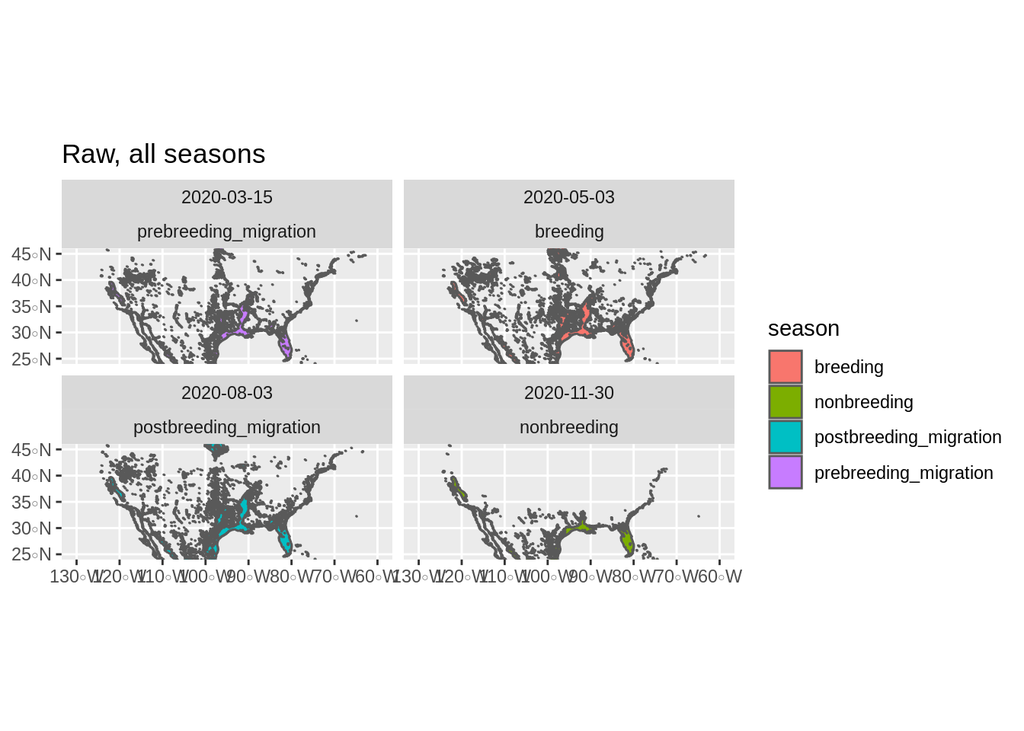

```r
## Data is divided by season:
snoegr_raw_range %>%
  ggplot( )+
  geom_sf( aes(fill = season), )+
  facet_wrap(start_dt~season)+
  ggtitle('Raw, all seasons')+
  coord_sf(ylim = c( 25,45),
           xlim = c(-130, -60))
```

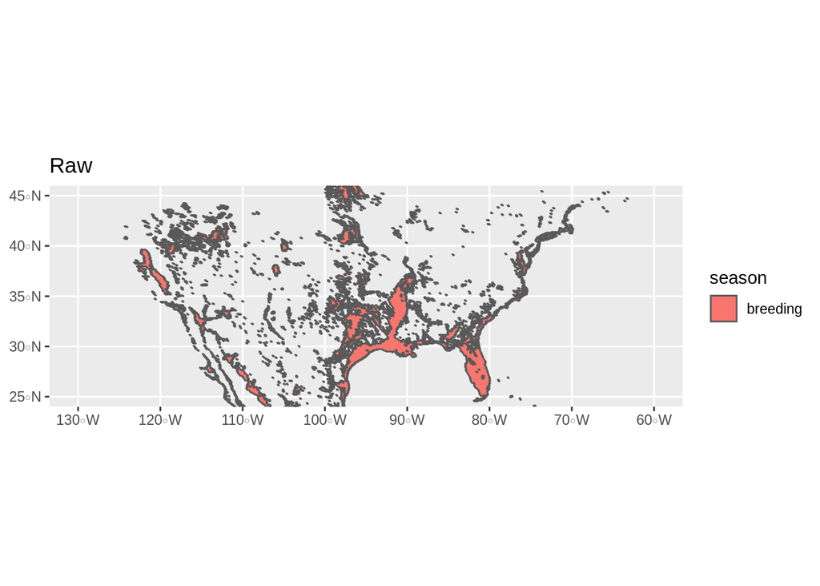

```r
snoegr_raw_range %>%
    filter(season == 'breeding' ) %>%
  ggplot( )+
  geom_sf( aes(fill = season))+
  ggtitle('Raw')+
  coord_sf(ylim = c( 25,45),
           xlim = c(-130, -60))
```

```r
##
snoegr_mr_range <- st_read('~/Downloads/all-range-2021.gpkg/snoegr-range-mr-2021.gpkg', layer = 'range')
```

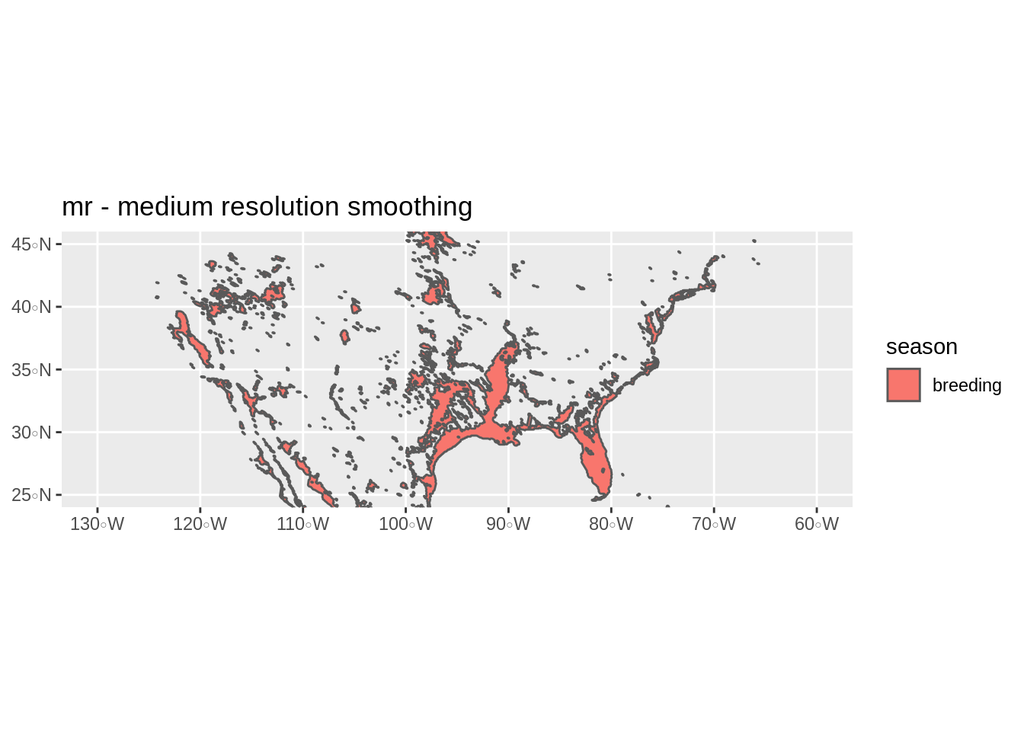

```r
snoegr_mr_range %>%
    filter(season == 'breeding' ) %>%
  ggplot( )+
  geom_sf( aes(fill = season))+
  ggtitle('mr - medium resolution smoothing')+
  coord_sf(ylim = c( 25,45),
           xlim = c(-130, -60))
```

```r
##
snoegr_lr_range <- st_read('~/Downloads/all-range-2021.gpkg/snoegr-range-lr-2021.gpkg', layer = 'range')
```

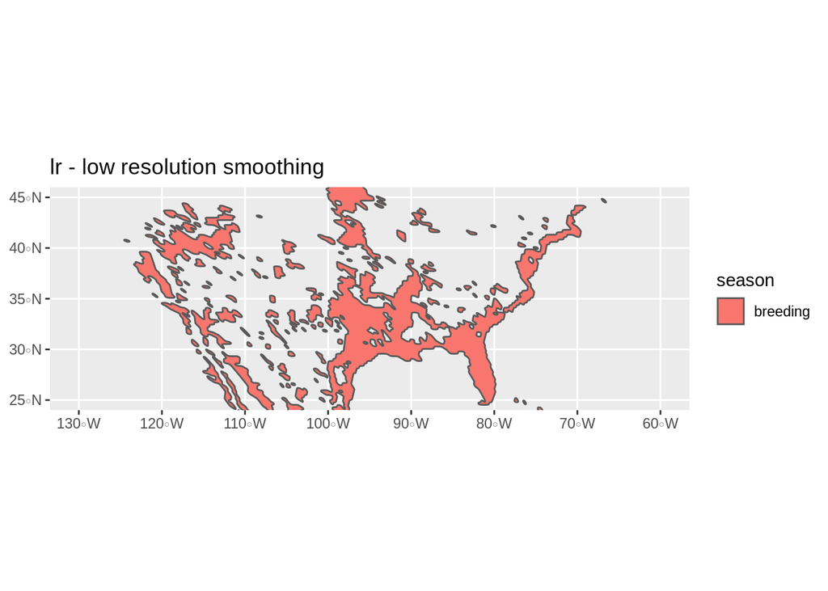

```r
snoegr_lr_range %>%
  filter(season == 'breeding' ) %>%
  ggplot( )+
  geom_sf( aes(fill = season))+
  ggtitle('lr - low resolution smoothing')+
  coord_sf(ylim = c( 25,45),
           xlim = c(-130, -60))
```

## Intersection of routes with example range

NB Original ebird CNRS = 4326, while route CNRS = 4269

Raw polygons take far too long to do anything useful with

```r
### First make a bounding box of the US
extent_ras <- extent(-150, -50, 20, 80)
extent_sf <- st_set_crs(st_as_sf(as(extent_ras, "SpatialPolygons")), 4269)

mr_breeding_snowegret <- filter(snoegr_mr_range, season == 'breeding' ) %>%
  st_transform(crs =4269 ) %>%
  st_crop(y = extent_sf)
```

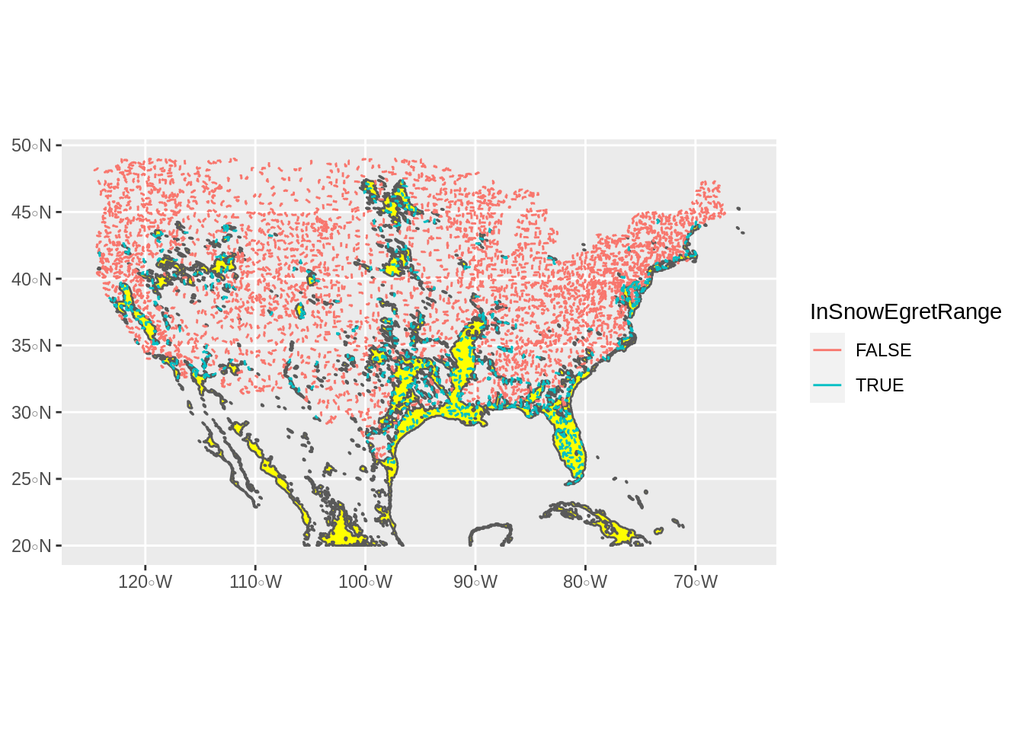

```r
InRange <- st_intersects(L48Routes$geometry,mr_breeding_snowegret$geom , sparse=FALSE) # takes 20 seconds or so for one species
L48Routes$InSnowEgretRange<- InRange[,1]

L48Routes %>%
  ggplot( )+
  geom_sf(data = mr_breeding_snowegret,
          aes(geometry = geom) , fill = 'yellow')+
  geom_sf(aes(geometry = geometry, col = InSnowEgretRange))
```

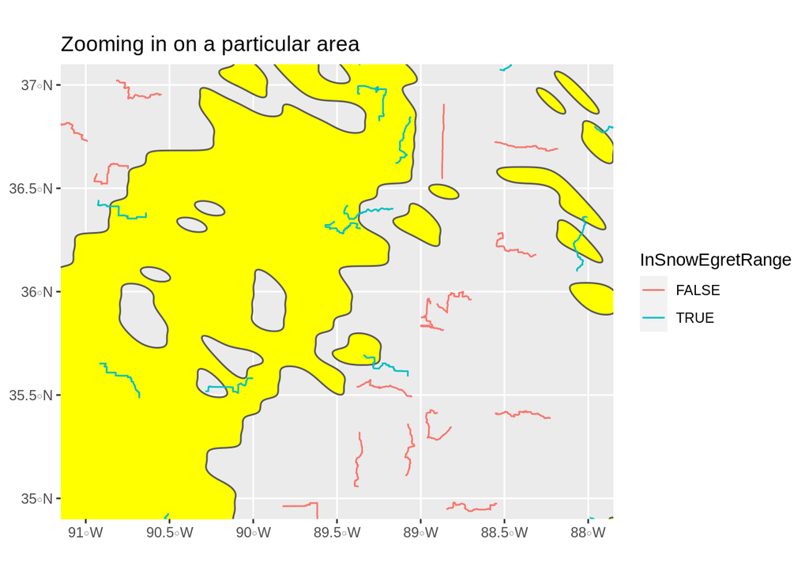

```r
L48Routes %>%
  ggplot( )+
  geom_sf(data = mr_breeding_snowegret,
          aes(geometry = geom) , fill = 'yellow')+
  geom_sf(aes(geometry = geometry, col = InSnowEgretRange))+
  coord_sf(xlim = c(-91, -88), ylim = c( 35,37))+
  ggtitle('Zooming in on a particular area')
```

# Full dataset

## Testing and matching names across datasets

```r
Species_formatted<- read_csv('../Data/2020Release_Nor/Species_formatted.csv' )
Consol_SpeciesNames<- read_csv('../Data/Consol_SpeciesNames.csv' )

Consol_SpeciesNames %>%
  left_join(Species_formatted, by = c('ConsolAOU' = 'aou' ) ) %>%
  rename(PostConsol_EnglishName = english_common_name,
         PreConsol_EnglishName = English_Common_Name) %>%
  select( -spanish_common_name            , -french_common_name ) %>%
   filter(!str_starts(PreConsol_EnglishName,'unid.'),
          !str_starts(PreConsol_EnglishName,'Unid.')) %>% #######################  Take out all the species labels that are unidentifiable between species
  mutate( ebird_ID_fromBinom =get_species(paste(genus,species)))-> Species_Names


nrow(distinct(Consol_SpeciesNames, ConsolAOU))  ## dataset has 379 consolidated species names in it = i.e. lumping together species that were considered one species at some point during the survey
```

```
## [1] 379
```

```r
### For those species that were lumped, need to have them 'unlumped' for the purpose of ebird maps
## Easiest way to do that is to use the pre-consolidation english names:

Species_Names %>%
  arrange(ConsolAOU ) %>%
  mutate( ebird_ID_fromCommon = get_species( PreConsol_EnglishName  )) -> Species_Names2
```

This leaves 21 species names in the BBS data that don’t have an easy analogue in the eBird dataset. Partly naming is not consistent between the datasets. eBird seems to be more up-to-date.

Still some species that should be available, but for some reason don’t have trends data available in ebird. e.g. Spot-breasted Oriole *Icterus pectoralis*, is all present and correct on the ebird website, https://ebird.org/species/spbori?siteLanguage=en_GB, but does not have a trend.

Fixing them manually where possible:

```r
Species_Names2 %>%
  filter(is.na(ebird_ID_fromBinom), is.na(ebird_ID_fromCommon)) %>%
  arrange(ConsolAOU ) %>%
  as.data.frame()
```

```
##      AOU                             PreConsol_EnglishName ConsolAOU
## 1   3010                                  Willow Ptarmigan      3010
## 2   3095                                    Indian Peafowl      3095
## 3   3152 African Collared-Dove (a.k.a. Ringed Turtle-Dove)      3152
## 4   3822                                        Budgerigar      3822
## 5   4120         (Yellow-shafted Flicker) Northern Flicker      4120
## 6   4130            (Red-shafted Flicker) Northern Flicker      4130
## 7   4730                                  Eurasian Skylark      4730
## 8   5032                              Spot-breasted Oriole      5032
## 9   5261                                European Goldfinch      5261
## 10  5660              (White-winged Junco) Dark-eyed Junco      5660
## 11  5670             (Slate-colored Junco) Dark-eyed Junco      5670
## 12  5671                    (Oregon Junco) Dark-eyed Junco      5671
## 13  5680                (Pink-sided Junco) Dark-eyed Junco      5680
## 14  5690               (Gray-headed Junco) Dark-eyed Junco      5690
```

[output cut: 73 more lines]

```r
Species_Names2 %>%
  mutate(ebird__ID_Manual =  ifelse(PreConsol_EnglishName =='Willow Ptarmigan','wilpta', NA ),
         ebird__ID_Manual =  ifelse(PreConsol_EnglishName %in% c('(Yellow-shafted Flicker) Northern Flicker',
                                                                 '(Red-shafted Flicker) Northern Flicker'),'norfli',ebird__ID_Manual ),
         ebird__ID_Manual =  ifelse(PreConsol_EnglishName =='Spot-breasted Oriole','spbori',ebird__ID_Manual ),
         ebird__ID_Manual =  ifelse(str_detect(PreConsol_EnglishName, 'Dark-eyed Junco'),'daejun',ebird__ID_Manual ),
         ebird__ID_Manual =  ifelse(PreConsol_EnglishName =="Botteri's Sparrow",'botspa',ebird__ID_Manual ),
         ebird__ID_Manual =  ifelse(str_detect(PreConsol_EnglishName, 'Yellow-rumped Warbler'),'yerwar',ebird__ID_Manual ),
         ebird__ID_Manual =  ifelse(PreConsol_EnglishName =='Bahama Mockingbird','bahmoc',ebird__ID_Manual ),
         ebird__ID_Manual =  ifelse(PreConsol_EnglishName =='Pin-tailed Whydah ','pitwhy',ebird__ID_Manual )
         ) -> Species_Names3

Species_Names3 %>%
mutate(ebird_ID_used = ifelse(!is.na(ebird__ID_Manual ),ebird__ID_Manual,
                              ifelse(  !is.na(ebird_ID_fromCommon ) ,ebird_ID_fromCommon,ebird_ID_fromBinom))) ->Species_Names_allcodes

Ebird_Codes <- unique(Species_Names_allcodes$ebird_ID_used)
```

```r
write_csv(Species_Names_allcodes, '../Data/Species_Names_allcodes.csv')
```

### Checking which have codes

```r
All_gpkg_names <- list.files('../../../Downloads/all-range-2021.gpkg/')
MR_names <-All_gpkg_names[str_detect(All_gpkg_names, 'range-mr') ]

ebird_codes_withmaps <-str_split(MR_names, '-', simplify = TRUE)[,1]

### Mostly weird species that fail
Species_Names_allcodes %>%
  filter( !(ebird_ID_used %in% ebird_codes_withmaps) )
```

```
## # A tibble: 15 x 14
##      AOU PreConsol_Engli… ConsolAOU ProblemTaxa species_id PostConsol_Engl…
##    <dbl> <chr>                <dbl> <lgl>            <dbl> <chr>
##  1  3095 Indian Peafowl        3095 FALSE              104 Indian Peafowl
##  2  3152 African Collare…      3152 FALSE              138 African Collare…
##  3  3822 Budgerigar            3822 FALSE              812 Budgerigar
##  4  4410 Broad-billed Hu…      4410 FALSE              248 Broad-billed Hu…
##  5  4730 Eurasian Skylark      4730 FALSE             1008 Eurasian Skylark
##  6  4890 Northwestern Cr…      4882 TRUE              1004 unid. American …
##  7  5032 Spot-breasted O…      5032 FALSE             1493 Spot-breasted O…
##  8  5261 European Goldfi…      5261 FALSE               NA <NA>
##  9  5760 Botteri's Sparr…      5760 FALSE             1376 Botteri's Sparr…
## 10  6000 Varied Bunting        6000 FALSE             1460 Varied Bunting
## 11  6990 Red-throated Pi…      6990 FALSE             1204 Red-throated Pi…
## 12  7031 Bahama Mockingb…      7031 FALSE             1177 Bahama Mockingb…
## 13  7240 Sedge Wren            7240 FALSE             1067 Sedge Wren
## 14 16600 Sinaloa Wren         16600 FALSE             1082 Sinaloa Wren
## 15 19510 Pin-tailed Whyd…     19510 FALSE               NA <NA>
## # … with 8 more variables: sporder <chr>, family <chr>, genus <chr>,
## #   species <chr>, ebird_ID_fromBinom <chr>, ebird_ID_fromCommon <chr>,
## #   ebird__ID_Manual <chr>, ebird_ID_used <chr>
```